# Spanish A/B Testing

Grace

4/2/2017

## Load library

```r
library(ggplot2)
suppressMessages(library(dplyr))
library(rpart)
suppressMessages(library(randomForest))
```

## Import dataset

```r
setwd("/Users/Grace/Desktop/Data Science/Samba TV")
user <- read.csv("user_table.csv")
test <- read.csv("test_table.csv")
```

## Initial check datasets

```r
str(user)
```

```
## 'data.frame':    452867 obs. of  4 variables:
##  $ user_id: int  765821 343561 118744 987753 554597 62371 987967 499510 364726 572551 ...
##  $ sex    : Factor w/ 2 levels "F","M": 2 1 2 1 1 2 2 1 1 2 ...
##  $ age    : int  20 27 23 27 20 29 31 29 29 21 ...
##  $ country: Factor w/ 17 levels "Argentina","Bolivia",..: 10 11 4 17 15 6 15 13 4 2 ...
```

```r
str(test)
```

```
## 'data.frame':    453321 obs. of  9 variables:
##  $ user_id         : int  315281 497851 848402 290051 548435 540675 863394 527287 261625 10427 ...
##  $ date            : Factor w/ 5 levels "2015-11-30","2015-12-01",..: 4 5 5 4 1 4 5 4 5 5 ...
##  $ source          : Factor w/ 3 levels "Ads","Direct",..: 2 1 1 1 1 2 3 2 2 1 ...
##  $ device          : Factor w/ 2 levels "Mobile","Web": 2 2 2 1 2 1 1 2 1 1 ...
##  $ browser_language: Factor w/ 3 levels "EN","ES","Other": 2 2 2 3 2 2 3 1 2 2 ...
##  $ ads_channel     : Factor w/ 5 levels "Bing","Facebook",..: NA 3 2 2 3 NA NA NA NA 2 ...
##  $ browser         : Factor w/ 7 levels "Android_App",..: 4 4 2 1 3 1 1 2 1 1 ...
##  $ conversion      : int  1 0 0 0 0 0 0 0 0 0 ...
##  $ test            : int  0 1 0 1 1 1 0 0 1 0 ...
```

Test table has more users than user table

```r
length(unique(test$user_id))-length(unique(user$user_id))
```

```
## [1] 454
```

To check whether test and user tables have duplicate user id, it turns out that there are no duplicates.

```r
length(unique(test$user_id))==nrow(test)
```

```
## [1] TRUE
```

```r
length(unique(user$user_id))==nrow(user)
```

```
## [1] TRUE
```

Since test table has more user_id records, I left join test table with user table to better preserve the record in test table. It is clearly that certain user_id is missing from user table. I would suggest to check with the team who collected the data to make sure the completeness and quality of the data.

```r
data <- merge(test, user, by="user_id", all.x=TRUE)
data$date <- as.Date(data$date) # convert to date format
summary(data)
```

```
##     user_id             date               source          device
##  Min.   :      1   Min.   :2015-11-30   Ads   :181877   Mobile:201756
##  1st Qu.: 249816   1st Qu.:2015-12-01   Direct: 90834   Web   :251565
##  Median : 500019   Median :2015-12-03   SEO   :180610
##  Mean   : 499938   Mean   :2015-12-02
##  3rd Qu.: 749522   3rd Qu.:2015-12-04
##  Max.   :1000000   Max.   :2015-12-04
##
##  browser_language   ads_channel            browser         conversion
##  EN   : 63137     Bing    : 13689   Android_App:155135   Min.   :0.00000
##  ES   :377547     Facebook: 68425   Chrome     :101929   1st Qu.:0.00000
##  Other: 12637     Google  : 68180   FireFox    : 40766   Median :0.00000
##                   Other   :  4148   IE         : 61715   Mean   :0.04958
##                   Yahoo   : 27435   Iphone_App : 46621   3rd Qu.:0.00000
##                   NA's    :271444   Opera      :  6090   Max.   :1.00000
##                                     Safari     : 41065
##       test          sex              age             country
##  Min.   :0.0000   F   :188382   Min.   :18.00   Mexico   :128484
##  1st Qu.:0.0000   M   :264485   1st Qu.:22.00   Colombia : 54060
##  Median :0.0000   NA's:   454   Median :26.00   Spain    : 51782
##  Mean   :0.4764                 Mean   :27.13   Argentina: 46733
##  3rd Qu.:1.0000                 3rd Qu.:31.00   Peru     : 33666
##  Max.   :1.0000                 Max.   :70.00   (Other)  :138142
##                                 NA's   :454     NA's     :   454
```

## Explotary Data Analysis

To start with, I would like to check whether Spain_based users have higher conversion rate than other Spanish-speaking countries.

```r
country <- data %>%
  group_by(country)%>%
  summarize(conversion_rate_control = mean(conversion[test== 0]),
            conversion_rate_test = mean(conversion[test== 1]),
            conversion_test_over_control =
              mean(conversion[test== 1])/mean(conversion[test==0]))%>%
  arrange(desc(conversion_rate_control))
head(country)
```

```
## # A tibble: 6 × 4
##       country conversion_rate_control conversion_rate_test
##        <fctr>                   <dbl>                <dbl>
## 1       Spain              0.07971882                  NaN
## 2          NA              0.07755102           0.05741627
## 3 El Salvador              0.05355404           0.04794689
## 4   Nicaragua              0.05264697           0.05417676
## 5  Costa Rica              0.05225564           0.05473764
## 6    Colombia              0.05208949           0.05057096
## # ... with 1 more variables: conversion_test_over_control <dbl>
```

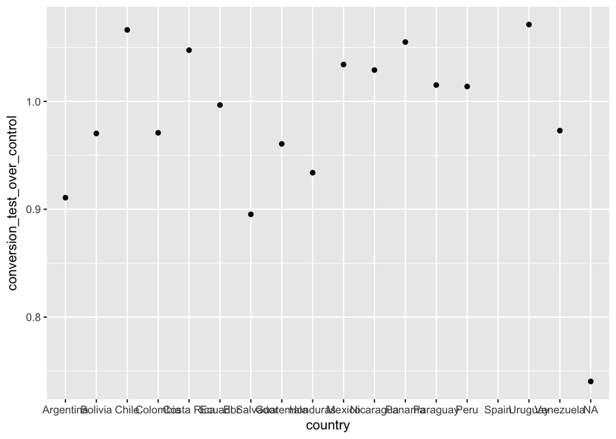

```r
qplot(x=country, y=conversion_test_over_control, data=country)
```

Spain does have the highest conversion rate in the control group. From the plot, we can tell that the some countries have higher conversion rate in test group while other countries didn’t.

## Leverage T Test to see whether the test and control groups have statistically significant result in conversion rate

```r
# Since nothing is changed in Spain, I simply remove Spain users from the test
newdata <- subset(data, country != 'Spain')
table(newdata$test)
```

```
##
##      0      1
## 185311 215774
```

```r
t.test(conversion~test, data=newdata)
```

```
##
##  Welch Two Sample t-test
##
## data:  conversion by test
## t = 7.3539, df = 385260, p-value = 1.929e-13
## alternative hypothesis: true difference in means is not equal to 0
## 95 percent confidence interval:
##  0.003579837 0.006181421
## sample estimates:
## mean in group 0 mean in group 1
##      0.04829179      0.04341116
```

The control group has a conversion rate of 4.8% while the test group is only at 4.3%. And it is statisitcally significant different among two groups.

Given the current circumstances, I can think of two potential reasons 1. There are not enough data 2. The experient was not conducted properly.

## Examine daily conversion rate of test group over control group

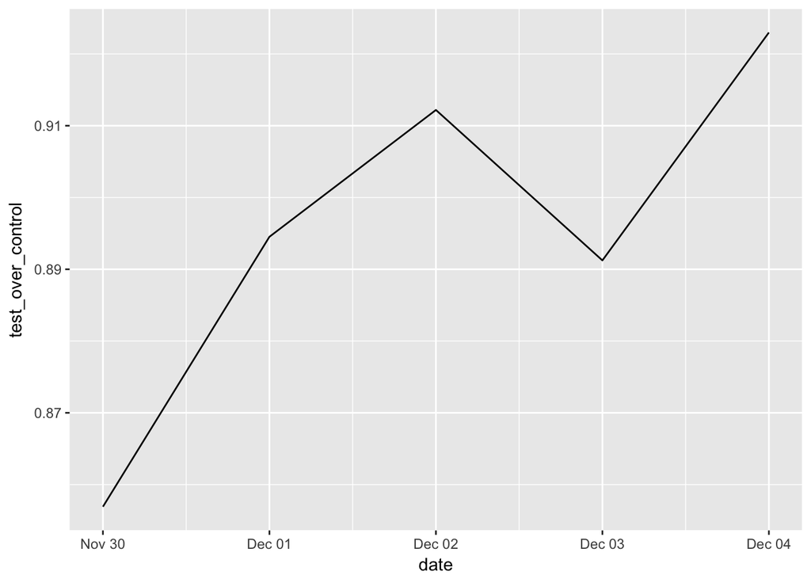

```r
daily_conversion <- newdata%>%
  group_by(date)%>%
  summarize(test_over_control = mean(conversion[test==1])/
              mean(conversion[test==0]))%>%
  arrange(date)
qplot(x=date,y=test_over_control, data=daily_conversion,
      geom = 'line')
```

From the daily converation rate plot, we can see that * 1. Test group is constantly performing worse than control for the whole test period. Even though there are fluctions in the conversion ration, the day-over-day variance is within reasonable range. * 2. The test only ran for 5 days. I would suggest to run the test for a month so that we can identify some trends. * 3. Even though 5 days of data are not perfect, they are good for an initial read. I think certain bias was introduced in this test.

## Examine whether the test set-up is valid

In order to examine whether the test and control groups are randomly selected, I recommend to leverage a simple decision tree in this case. If the random selection is implemented properly, it is impossible to classify the users into test or control groups. In other words, the decision tree would fail to separate the two groups.

```r
set.seed(0)
tree <- rpart(test~., data=newdata[,-8], maxdepth=5)
tree
```

```
## n= 401085
##
## node), split, n, deviance, yval
##       * denotes terminal node
##
## 1) root 401085 99692.820 0.5379757
##   2) country=Bolivia,Chile,Colombia,Costa Rica,Ecuador,El Salvador,Guatemala,Honduras,Mexico,Nicaragua,Panama,Paraguay,Peru,Venezuela 350218 87553.970 0.4987693 *
##   3) country=Argentina,Uruguay 50867  7894.097 0.8079108 *
```

## Calculate propensity score

This is to double check the result we obtained from decision trees.

```r
# to remove user_id, date, conversionfrom the dataset to fit the model
data2 <- subset(newdata[,-c(1,2,8)],!is.na(country))
data2$ads_channel <- as.factor(ifelse(is.na(data2$ads_channel), 'Other', data2$ads_channel))
data2$test = as.factor(data2$test)
```

```r
glm <- glm(test~., family=binomial(link="logit") ,data = data2)
data2$pscore <- predict(glm, newdata = data2, type = "response")
```

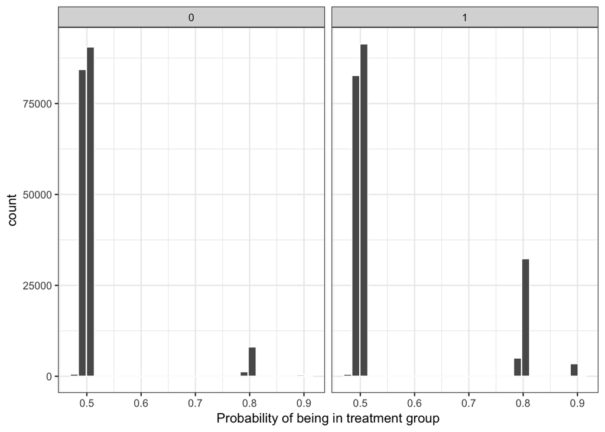

```r
ggplot(data2, aes(x = pscore)) + geom_histogram(color = "white") + facet_wrap(~test) + xlab("Probability of being in treatment group") + theme_bw()
```

```r
summary(glm)
```

```
##
## Call:
## glm(formula = test ~ ., family = binomial(link = "logit"), data = data2)
##
## Deviance Residuals:
##     Min       1Q   Median       3Q      Max
## -2.1615  -1.1759   0.6659   1.1772   1.2267
##
## Coefficients: (2 not defined because of singularities)
##                         Estimate Std. Error  z value Pr(>|z|)
## (Intercept)            1.4163421  0.0271860   52.098  < 2e-16 ***
## sourceDirect          -0.0123023  0.0200206   -0.614  0.53890
## sourceSEO              0.0023661  0.0193582    0.122  0.90272
## deviceWeb             -0.0338932  0.0120803   -2.806  0.00502 **
## browser_languageES    -0.0071037  0.0093696   -0.758  0.44835
## browser_languageOther  0.0122263  0.0212481    0.575  0.56502
## ads_channel2           0.0020619  0.0204460    0.101  0.91967
## ads_channel3          -0.0084902  0.0204495   -0.415  0.67801
## ads_channel4          -0.0407715  0.0387261   -1.053  0.29243
## ads_channel5          -0.0133946  0.0228277   -0.587  0.55736
## ads_channelOther              NA         NA       NA       NA
## browserChrome          0.0411296  0.0127271    3.232  0.00123 **
## browserFireFox         0.0256783  0.0152394    1.685  0.09199 .
## browserIE              0.0196295  0.0138639    1.416  0.15681
## browserIphone_App     -0.0094543  0.0115121   -0.821  0.41150
## browserOpera           0.0212749  0.0299462    0.710  0.47743
## browserSafari                 NA         NA       NA       NA
## sexM                  -0.0007732  0.0065683   -0.118  0.90629
## age                   -0.0006015  0.0004779   -1.259  0.20815
## countryBolivia        -1.3806168  0.0222096  -62.163  < 2e-16 ***
## countryChile          -1.3816470  0.0183394  -75.338  < 2e-16 ***
## countryColombia       -1.3893375  0.0144099  -96.416  < 2e-16 ***
## countryCosta Rica     -1.3890017  0.0297855  -46.634  < 2e-16 ***
## countryEcuador        -1.4074286  0.0196305  -71.696  < 2e-16 ***
## countryEl Salvador    -1.3953649  0.0249601  -55.904  < 2e-16 ***
## countryGuatemala      -1.4008061  0.0199538  -70.203  < 2e-16 ***
## countryHonduras       -1.4209626  0.0245092  -57.977  < 2e-16 ***
## countryMexico         -1.3840804  0.0128367 -107.822  < 2e-16 ***
## countryNicaragua      -1.4190005  0.0269975  -52.561  < 2e-16 ***
## countryPanama         -1.3757700  0.0338552  -40.637  < 2e-16 ***
## countryParaguay       -1.3722523  0.0260414  -52.695  < 2e-16 ***
## countryPeru           -1.3894299  0.0158893  -87.445  < 2e-16 ***
## countryUruguay         0.8078026  0.0530268   15.234  < 2e-16 ***
## countryVenezuela      -1.4001315  0.0160764  -87.092  < 2e-16 ***
## ---
## Signif. codes:  0 '***' 0.001 '**' 0.01 '*' 0.05 '.' 0.1 ' ' 1
##
## (Dispersion parameter for binomial family taken to be 1)
##
##     Null deviance: 553706  on 401084  degrees of freedom
## Residual deviance: 534965  on 401053  degrees of freedom
## AIC: 535029
##
## Number of Fisher Scoring iterations: 4
```

The plot shows different distributions in test and control groups. Therefore, pre-selection bias exists in this test, which ruined the randomization. Both decision tree and propensity score confirms the existence of pre-selection bias.

Specifically, from the coefficients and p-value of the logistic regression. We can infer that the bias was introduced by all the significant variables. The most significant ones are Country Bolivia, Chile, Colombia, Costa Rica, Ecuador, EL Salvador, Guatemala, Honduras, Mexico, Nicaragua, Panama, Paraguay, Peru, Uruguay, Venezuela. This is consistent with the result of the decision tree. The next sinificant variables include deviceWeb and browserChrome.

In this case, I would recommend to stratefy the variables listed above during the random selection in order to avoid bias.

## To check whether the test is significant by controlling country

```r
country = unique(newdata$country)
p.value = rep(0,length(unique(country)))
conversion.test = p.value
conversion.control = p.value

for (i in 1:length(country)){
  temp <- subset(newdata, newdata$country== country[i])
  p.value[i] = t.test(conversion~test, data=temp)$p.value
  conversion.test[i] = t.test(conversion~test, data=temp)$estimate[2]
  conversion.control[i] = t.test(conversion~test, data=temp)$estimate[1]
}
df <- data.frame(country,p.value,conversion.test, conversion.control)
df
```

[output not shown]

On the country level, the test appears to be insignificant. Therefore, we can conclude that a localized translation didn’t make conversion rate worse. To redesign the randomization process and to extend the experimental period to a month will help us better understand whether a localized translation will actually improve conversion rate along with any potential seasonality impact.

[output not shown]